# Orange Juice Production

This notebook analyzes a simplified orange juice production process. The problem relates to a 2-stage process in which oranges are first crushed, and then strained. The input is whole oranges, which are considered to be 80% water, and 20% solids. The mass density of the solids in the oranges is 1.540 $\mathrm{g.cm^{-3}}$. The juice leaves the strainer through a pipe with an 8 inch radius, with a flow speed of 30 m/s. The strainer removes 90% of the solids.

Find:

- The mass flow rate of orange juice product
- The process throughput in number of oranges per year, if the process is run 8 hours per day, 360 days per year.

### We need to perform the degree of freedom analysis. A sketch of the problem is shown below.

# Process Diagram

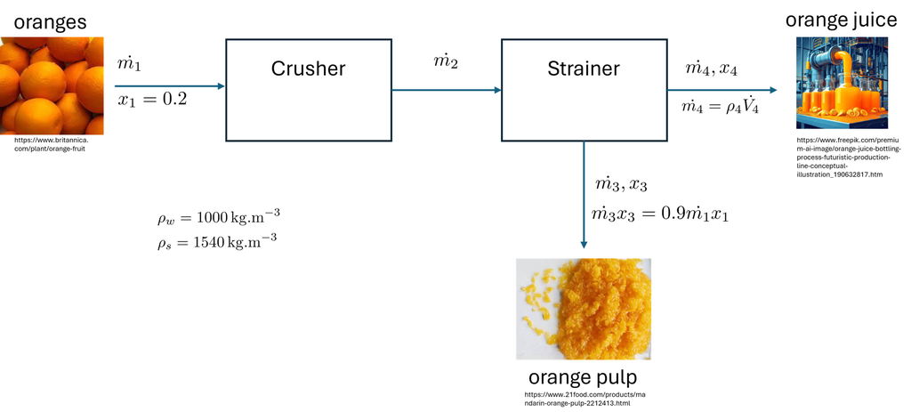

# Mass Balance Calculation

First, consider the system overall (subsystem analysis can also be done, but it is not necessary, strictly speaking).

- Since there are no chemical reactions involving water or the solids, the amount of water that comes in must also be the amount of water that leaves, and the same is true for the solids.

We therefore write for water, and solids, respectively:

\begin{equation} \dot{m_1}(1-x_1) = \dot{m_3}(1-x_3) + \dot{m_4}(1-x_4) \tag{1}\label{water_balance} \end{equation}\begin{equation} \dot{m_1}x_1 = \dot{m_3}x_3 + \dot{m_4}x_4 \tag{2}\label{solids_balance} \end{equation}

We could also write the mass balance of the system overall, i.e.:

\begin{equation} \dot{m_1} = \dot{m_3} + \dot{m_4} \tag{3}\label{overall_balance} \end{equation}

Note however that the above equation for overall mass balance is simply the linear sum of the component balances themselves. Two things: First, this is true by definition - if you add up all the components you get the overall mass in the system. Second, and more importantly, if we do the individual component mass balance, analyzing the overall mass balance will not yield new information, as the overall balance is just a linear combination of already known information. So, based on the component balances written above, we have 5 unknowns, *viz.* $\dot{m_1}, \dot{m_3}, \dot{m_4}, x_3, x_4$. The composition of the inlet stream, $x_1$, is given by the problem as 20% or 0.2, and is therefore not an unknown.

We have 2 relationships we can write.

- First, we recognize that the mass flow rate of juice is related to the given volumetric flow rate (the product of the cross sectional area of the pipe the linear velocity of the juice) by the average density of the juice. The average juice density depends on the mass fraction of solids in the juice. The volumetric flow rate $\dot{V}$ is the product of the flow rate (30 m/s) and the cross sectional area of the circular pipe, so $\dot{V_4} = v.\pi R^2$. The mass flow rate of produced juice is then

\begin{equation} \dot{m_4} = \rho_4 \dot{V_4} \tag{4}\label{relationship_density} \end{equation}

where $\rho_4$ is the mass density of stream 4. We know the (average) mass density of a multicomponent system is given by $\bar{\rho} = \sum_i m_i/\sum_i v_i$, where $m_i$ and $v_i$ are the mass and volume of each component. Per unit mass of the system, the mass of component $i$ is simply $x_i$, i.e. the mass fraction of species $i$. Therefore,

\begin{equation} \rho_4 = \frac{x_4 + (1-x_4)}{(x_4/\rho_s) + ((1-x_4)/\rho_w)} = \frac{\rho_w}{x_4[(\rho_w/\rho_s) - 1] + 1} \end{equation}

- Secondly, we are told that 90% of the solids are removed by the strainer, so

\begin{equation} \dot{m_3}x_3 = 0.9\dot{m_1}x_1 \tag{5}\label{relationship_solids} \end{equation}

Now - for our degree of freedom analysis. We have:

- 5 unknowns
- 2 component mass balance equations
- 2 relationships among variables.

We therefore have 1 degree of freedom, so the problem is underspecified.

We could also arrive at this by looking at the subunits. On the strainer:

- 6 unknowns: $\dot{m_2}, x_2, \dot{m_3}, x_3, \dot{m_4}$ and $x_4$.
- We can write 2 mass balances, 1 for each component (water; solids)
- Information: solids capture (90%) and mass flow rate of product as a function of only one component concentration (the mass of solids in stream 1) provides 2 pieces of information.
- Degrees of Freedom = 6-2-2 = 2.

On the crusher:

- 3 unknowns: $\dot{m_1}, \dot{m_2}$ and $x_2$
- 2 independent mass balances
- Degrees of freedom = 3-2 = 1.

Overall: 2 +1 = 3 DOF; 2 Intermediate variables ($\dot{m_2}$ and $x_2$), so total DOF = 3-2 = 1. Again, from the sub-unit analysis, we see the problem is underspecified.

**Make an assumption to constrain the problem**

A reasonable assumption to make is that the water content in the material produced by the strainer is negligible, i.e. $x_3\approx 1$.

With this, we can go ahead and solve the problem.

Now, if we use Eq. $\eqref{relationship_solids}$ in Eq. $\eqref{solids_balance}$, we get

\begin{equation} \dot{m_1} = 50\dot{m_4}x_4 \tag{6}\label{new_equation_1} \end{equation}

If we now use Eq. $\eqref{new_equation_1}$ in Eq. $\eqref{water_balance}$, we get that

\begin{equation} \dot{m_4}(41x_4 -1)=0 \end{equation}

Either $\dot{m_4}$ is zero, or $x_4 = 1/41 \approx 0.0244$. The latter is the solution of interest (we are told that there is a finite flow of juice produced).

From here, we can go back and find the other quantities of interest, leading to:

- $\dot{m_4} = 3923.5\, \mathrm{kg/s}$
- $\dot{m_1} = 4784.8\, \mathrm{kg/s}$

Finally, to find the rate of production, we divide the mass flow rate $\dot{m_1}$ by the mass of an orange to get oranges per second. Then, we have 3600 s/hr, 8 hr/day and 360 days/yr, so the total is $\mathrm{1.24\times 10^{11}}$ oranges per year.